# Convolutional Neural Networks

## Project: Write an Algorithm for a Dog Identification App

In this notebook, some template code has already been provided for you, and you will need to implement additional functionality to successfully complete this project. You will not need to modify the included code beyond what is requested. Sections that begin with **'(IMPLEMENTATION)'** in the header indicate that the following block of code will require additional functionality which you must provide. Instructions will be provided for each section, and the specifics of the implementation are marked in the code block with a 'TODO' statement. Please be sure to read the instructions carefully!

> **Note**: Once you have completed all of the code implementations, you need to finalize your work by exporting the Jupyter Notebook as an HTML document. Before exporting the notebook to html, all of the code cells need to have been run so that reviewers can see the final implementation and output. You can then export the notebook by using the menu above and navigating to **File -> Download as -> HTML (.html)**. Include the finished document along with this notebook as your submission.

In addition to implementing code, there will be questions that you must answer which relate to the project and your implementation. Each section where you will answer a question is preceded by a **'Question X'** header. Carefully read each question and provide thorough answers in the following text boxes that begin with **'Answer:'**. Your project submission will be evaluated based on your answers to each of the questions and the implementation you provide.

> **Note:** Code and Markdown cells can be executed using the **Shift + Enter** keyboard shortcut. Markdown cells can be edited by double-clicking the cell to enter edit mode.

The rubric contains *optional* "Stand Out Suggestions" for enhancing the project beyond the minimum requirements. If you decide to pursue the "Stand Out Suggestions", you should include the code in this Jupyter notebook.

### Why We're Here

In this notebook, you will make the first steps towards developing an algorithm that could be used as part of a mobile or web app. At the end of this project, your code will accept any user-supplied image as input. If a dog is detected in the image, it will provide an estimate of the dog's breed. If a human is detected, it will provide an estimate of the dog breed that is most resembling. The image below displays potential sample output of your finished project (... but we expect that each student's algorithm will behave differently!).

[figure not shown]

In this real-world setting, you will need to piece together a series of models to perform different tasks; for instance, the algorithm that detects humans in an image will be different from the CNN that infers dog breed. There are many points of possible failure, and no perfect algorithm exists. Your imperfect solution will nonetheless create a fun user experience!

### The Road Ahead

We break the notebook into separate steps. Feel free to use the links below to navigate the notebook.

- Step 0: Import Datasets
- Step 1: Detect Humans
- Step 2: Detect Dogs
- Step 3: Create a CNN to Classify Dog Breeds (from Scratch)
- Step 4: Create a CNN to Classify Dog Breeds (using Transfer Learning)
- Step 5: Write your Algorithm
- Step 6: Test Your Algorithm

## Step 0: Import Datasets

Make sure that you've downloaded the required human and dog datasets:

- Download the [dog dataset](https://s3-us-west-1.amazonaws.com/udacity-aind/dog-project/dogImages.zip). Unzip the folder and place it in this project's home directory, at the location `/dogImages`.
- Download the [human dataset](https://s3-us-west-1.amazonaws.com/udacity-aind/dog-project/lfw.zip). Unzip the folder and place it in the home diretcory, at location `/lfw`.

*Note: If you are using a Windows machine, you are encouraged to use [7zip](http://www.7-zip.org/) to extract the folder.*

In the code cell below, we save the file paths for both the human (LFW) dataset and dog dataset in the numpy arrays `human_files` and `dog_files`.

```python
from sklearn.datasets import load_files
from keras.utils import np_utils
import numpy as np
from glob import glob

# define function to load train, test, and validation datasets
def load_dataset(path):
    data = load_files(path)
    dog_files = np.array(data['filenames'])
    dog_targets = np_utils.to_categorical(np.array(data['target']), 133)
    return dog_files, dog_targets

# load train, test, and validation datasets
train_files, train_targets = load_dataset('dogImages/train')
valid_files, valid_targets = load_dataset('dogImages/valid')
test_files, test_targets = load_dataset('dogImages/test')

# load list of dog names
dog_names = [item[20:-1] for item in sorted(glob("dogImages/train/*/"))]

# print statistics about the dataset
print('There are %d total dog categories.' % len(dog_names))
print('There are %s total dog images.\n' % len(np.hstack([train_files, valid_files, test_files])))
print('There are %d training dog images.' % len(train_files))
print('There are %d validation dog images.' % len(valid_files))
print('There are %d test dog images.'% len(test_files))
```

```
There are 133 total dog categories.
There are 8351 total dog images.

There are 6680 training dog images.
There are 835 validation dog images.
There are 836 test dog images.
```

## Import Human Dataset

```python
import random
random.seed(8675309)

# load filenames in shuffled human dataset
human_files = np.array(glob("lfw/*/*"))
random.shuffle(human_files)

# print statistics about the dataset
print('There are %d total human images.' % len(human_files))
```

```
There are 13233 total human images.
```

## Step 1: Detect Humans

In this section, we use OpenCV's implementation of [Haar feature-based cascade classifiers](http://docs.opencv.org/trunk/d7/d8b/tutorial_py_face_detection.html) to detect human faces in images.

OpenCV provides many pre-trained face detectors, stored as XML files on [github](https://github.com/opencv/opencv/tree/master/data/haarcascades). We have downloaded one of these detectors and stored it in the `haarcascades` directory. In the next code cell, we demonstrate how to use this detector to find human faces in a sample image.

```
Number of faces detected: 1
```

[figure not shown]

```python
import cv2
import matplotlib.pyplot as plt
%matplotlib inline

# extract pre-trained face detector
face_cascade = cv2.CascadeClassifier('haarcascades/haarcascade_frontalface_alt.xml')

# load color (BGR) image
img = cv2.imread(human_files[0])
# convert BGR image to grayscale
gray = cv2.cvtColor(img, cv2.COLOR_BGR2GRAY)

# find faces in image
faces = face_cascade.detectMultiScale(gray)

# print number of faces detected in the image
print('Number of faces detected:', len(faces))

# get bounding box for each detected face
for (x,y,w,h) in faces:
    # add bounding box to color image
    cv2.rectangle(img,(x,y),(x+w,y+h),(255,0,0),2)

# convert BGR image to RGB for plotting
cv_rgb = cv2.cvtColor(img, cv2.COLOR_BGR2RGB)

# display the image, along with bounding box
plt.imshow(cv_rgb)
plt.show()
```

Before using any of the face detectors, it is standard procedure to convert the images to grayscale. The `detectMultiScale` function executes the classifier stored in `face_cascade` and takes the grayscale image as a parameter.

In the above code, `faces` is a numpy array of detected faces, where each row corresponds to a detected face. Each detected face is a 1D array with four entries that specifies the bounding box of the detected face. The first two entries in the array (extracted in the above code as `x` and `y`) specify the horizontal and vertical positions of the top left corner of the bounding box. The last two entries in the array (extracted here as `w` and `h`) specify the width and height of the box.

### Write a Human Face Detector

We can use this procedure to write a function that returns `True` if a human face is detected in an image and `False` otherwise. This function, aptly named `face_detector`, takes a string-valued file path to an image as input and appears in the code block below.

```python
# returns "True" if face is detected in image stored at img_path
def face_detector(img_path):
    img = cv2.imread(img_path)
    gray = cv2.cvtColor(img, cv2.COLOR_BGR2GRAY)
    faces = face_cascade.detectMultiScale(gray)
    return len(faces) > 0
```

### (IMPLEMENTATION) Assess the Human Face Detector

**Question 1:** Use the code cell below to test the performance of the `face_detector` function.

- What percentage of the first 100 images in `human_files` have a detected human face?
- What percentage of the first 100 images in `dog_files` have a detected human face?

Ideally, we would like 100% of human images with a detected face and 0% of dog images with a detected face. You will see that our algorithm falls short of this goal, but still gives acceptable performance. We extract the file paths for the first 100 images from each of the datasets and store them in the numpy arrays `human_files_short` and `dog_files_short`.

**Answer:** Percentage of the first 100 images in human_files have a detected human face is 97.0

Percentage of the first 100 images in dog_files that detected human face is 12.0

```python
from tqdm import tqdm

human_files_short = human_files[:100]
dog_files_short = train_files[:100]
check_human = 0
check_dog = 0
#-#-# Do NOT modify the code above this line. #-#-#

## TODO: Test the performance of the face_detector algorithm
## on the images in human_files_short and dog_files_short.
for img in human_files_short:
    if face_detector(img):
        check_human += 1
for img in dog_files_short:
    if face_detector(img):
        check_dog += 1
per_human = (check_human /len(human_files_short)) * 100
per_dog = (check_dog / len(dog_files_short)) * 100
print("Percentage of the first 100 images in human_files have a detected human face is {}".format(per_human))
print("Percentage of the first 100 images in dog_files that detected human face is {}".format(per_dog))
```

```
Percentage of the first 100 images in human_files have a detected human face is 97.0
Percentage of the first 100 images in dog_files that detected human face is 12.0
```

We suggest the face detector from OpenCV as a potential way to detect human images in your algorithm, but you are free to explore other approaches, especially approaches that make use of deep learning :). Please use the code cell below to design and test your own face detection algorithm. If you decide to pursue this *optional* task, report performance on `human_files_short` and `dog_files_short`.

```python
### (Optional)
### TODO: Test performance of anotherface detection algorithm.
### Feel free to use as many code cells as needed.
```

## Step 2: Detect Dogs

In this section, we use a [pre-trained model](http://pytorch.org/docs/master/torchvision/models.html) to detect dogs in images.

### Obtain Pre-trained VGG-16 Model

The code cell below downloads the VGG-16 model, along with weights that have been trained on [ImageNet](http://www.image-net.org/), a very large, very popular dataset used for image classification and other vision tasks. ImageNet contains over 10 million URLs, each linking to an image containing an object from one of [1000 categories](https://gist.github.com/yrevar/942d3a0ac09ec9e5eb3a).

```python
from keras.applications.vgg16 import VGG16

# define ResNet50 model
Vgg16_model = VGG16(weights='imagenet')
```

```python
from keras.applications.resnet50 import ResNet50

# define ResNet50 model
ResNet50_model = ResNet50(weights='imagenet')
```

## Pre-process the Data

When using TensorFlow as backend, Keras CNNs require a 4D array (which we'll also refer to as a 4D tensor) as input, with shape $$ (\text{nb_samples}, \text{rows}, \text{columns}, \text{channels}), $$

where nb_samples corresponds to the total number of images (or samples), and rows, columns, and channels correspond to the number of rows, columns, and channels for each image, respectively.

The path_to_tensor function below takes a string-valued file path to a color image as input and returns a 4D tensor suitable for supplying to a Keras CNN. The function first loads the image and resizes it to a square image that is $224 \times 224$ pixels. Next, the image is converted to an array, which is then resized to a 4D tensor. In this case, since we are working with color images, each image has three channels. Likewise, since we are processing a single image (or sample), the returned tensor will always have shape $$ (1, 224, 224, 3). $$

The paths_to_tensor function takes a numpy array of string-valued image paths as input and returns a 4D tensor with shape $$ (\text{nb_samples}, 224, 224, 3). $$

Here, nb_samples is the number of samples, or number of images, in the supplied array of image paths. It is best to think of nb_samples as the number of 3D tensors (where each 3D tensor corresponds to a different image) in your dataset!

Given an image, this pre-trained VGG-16 model returns a prediction (derived from the 1000 possible categories in ImageNet) for the object that is contained in the image.

```python
from keras.preprocessing import image
from tqdm import tqdm

def path_to_tensor(img_path):
    # loads RGB image as PIL.Image.Image type
    img = image.load_img(img_path, target_size=(224, 224))
    # convert PIL.Image.Image type to 3D tensor with shape (224, 224, 3)
    x = image.img_to_array(img)
    # convert 3D tensor to 4D tensor with shape (1, 224, 224, 3) and return 4D tensor
    return np.expand_dims(x, axis=0)

def paths_to_tensor(img_paths):
    list_of_tensors = [path_to_tensor(img_path) for img_path in tqdm(img_paths)]
    return np.vstack(list_of_tensors)
```

### (IMPLEMENTATION) Making Predictions with a Pre-trained Model

In the next code cell, you will write a function that accepts a path to an image (such as `'dogImages/train/001.Affenpinscher/Affenpinscher_00001.jpg'`) as input and returns the index corresponding to the ImageNet class that is predicted by the pre-trained VGG-16 model. The output should always be an integer between 0 and 999, inclusive.

Before writing the function, make sure that you take the time to learn how to appropriately pre-process tensors for pre-trained models in the [PyTorch documentation](http://pytorch.org/docs/stable/torchvision/models.html).

```python
from keras.applications.vgg16 import preprocess_input, decode_predictions

def Vgg16_predict_labels(img_path):
    # returns prediction vector for image located at img_path
    img = preprocess_input(path_to_tensor(img_path))
    return np.argmax(Vgg16_model.predict(img))
```

```python
from keras.applications.resnet50 import preprocess_input, decode_predictions

def ResNet50_predict_labels(img_path):
    # returns prediction vector for image located at img_path
    img = preprocess_input(path_to_tensor(img_path))
    return np.argmax(ResNet50_model.predict(img))
```

### (IMPLEMENTATION) Write a Dog Detector

While looking at the [dictionary](https://gist.github.com/yrevar/942d3a0ac09ec9e5eb3a), you will notice that the categories corresponding to dogs appear in an uninterrupted sequence and correspond to dictionary keys 151-268, inclusive, to include all categories from `'Chihuahua'` to `'Mexican hairless'`. Thus, in order to check to see if an image is predicted to contain a dog by the pre-trained VGG-16 model, we need only check if the pre-trained model predicts an index between 151 and 268 (inclusive).

Use these ideas to complete the `dog_detector` function below, which returns `True` if a dog is detected in an image (and `False` if not).

```python
### returns "True" if a dog is detected in the image stored at img_path
#def dog_detector(img_path):
    #prediction = Vgg16_predict_labels(img_path)
    #return ((prediction <= 268) & (prediction >= 151))
```

```python
### returns "True" if a dog is detected in the image stored at img_path
def dog_detector(img_path):
    prediction = ResNet50_predict_labels(img_path)
    return ((prediction <= 268) & (prediction >= 151))
```

### (IMPLEMENTATION) Assess the Dog Detector

**Question 2:** Use the code cell below to test the performance of your `dog_detector` function.

- What percentage of the images in `human_files_short` have a detected dog?
- What percentage of the images in `dog_files_short` have a detected dog?

**Answer:**

```python
### TODO: Test the performance of the dog_detector function
### on the images in human_files_short and dog_files_short.
human_files_short = human_files[:100]
dog_files_short = train_files[:100]
### TODO: Test the performance of the dog_detector function
### on the images in human_files_short and dog_files_short.
check_human = 0
check_dog = 0

for img in human_files_short:
    if dog_detector(img):
        check_human += 1
for img in dog_files_short:
    if dog_detector(img):
        check_dog += 1
per_human = (check_human /len(human_files_short)) * 100
per_dog = (check_dog / len(dog_files_short)) * 100
print("Percentage of the images in human_files_short have a detected dog is {}".format(per_human))
print("Percentage of the images in dog_files_short have a detected dog is {}".format(per_dog))
```

```
Percentage of the images in human_files_short have a detected dog is 2.0
Percentage of the images in dog_files_short have a detected dog is 100.0
```

We suggest VGG-16 as a potential network to detect dog images in your algorithm, but you are free to explore other pre-trained networks (such as [Inception-v3](http://pytorch.org/docs/master/torchvision/models.html#inception-v3), [ResNet-50](http://pytorch.org/docs/master/torchvision/models.html#id3), etc). Please use the code cell below to test other pre-trained PyTorch models. If you decide to pursue this *optional* task, report performance on `human_files_short` and `dog_files_short`.

```python
### (Optional)
### TODO: Report the performance of another pre-trained network.
### Feel free to use as many code cells as needed.
```

## Step 3: Create a CNN to Classify Dog Breeds (from Scratch)

Now that we have functions for detecting humans and dogs in images, we need a way to predict breed from images. In this step, you will create a CNN that classifies dog breeds. You must create your CNN *from scratch* (so, you can't use transfer learning *yet*!), and you must attain a test accuracy of at least 10%. In Step 4 of this notebook, you will have the opportunity to use transfer learning to create a CNN that attains greatly improved accuracy.

We mention that the task of assigning breed to dogs from images is considered exceptionally challenging. To see why, consider that *even a human* would have trouble distinguishing between a Brittany and a Welsh Springer Spaniel.

| Brittany | Welsh Springer Spaniel |
| --- | --- |

It is not difficult to find other dog breed pairs with minimal inter-class variation (for instance, Curly-Coated Retrievers and American Water Spaniels).

| Curly-Coated Retriever | American Water Spaniel |
| --- | --- |

Likewise, recall that labradors come in yellow, chocolate, and black. Your vision-based algorithm will have to conquer this high intra-class variation to determine how to classify all of these different shades as the same breed.

| Yellow Labrador | Chocolate Labrador | Black Labrador |
| --- | --- | --- |

We also mention that random chance presents an exceptionally low bar: setting aside the fact that the classes are slightly imabalanced, a random guess will provide a correct answer roughly 1 in 133 times, which corresponds to an accuracy of less than 1%.

Remember that the practice is far ahead of the theory in deep learning. Experiment with many different architectures, and trust your intuition. And, of course, have fun!

### (IMPLEMENTATION) Specify Data Loaders for the Dog Dataset

Use the code cell below to write three separate [data loaders](http://pytorch.org/docs/stable/data.html#torch.utils.data.DataLoader) for the training, validation, and test datasets of dog images (located at `dogImages/train`, `dogImages/valid`, and `dogImages/test`, respectively). You may find [this documentation on custom datasets](http://pytorch.org/docs/stable/torchvision/datasets.html) to be a useful resource. If you are interested in augmenting your training and/or validation data, check out the wide variety of [transforms](http://pytorch.org/docs/stable/torchvision/transforms.html?highlight=transform)!

## Pre-process the Data

We rescale the images by dividing every pixel in every image by 255.

```python
from PIL import ImageFile
ImageFile.LOAD_TRUNCATED_IMAGES = True

# pre-process the data for Keras
train_tensors = paths_to_tensor(train_files).astype('float32')/255
valid_tensors = paths_to_tensor(valid_files).astype('float32')/255
test_tensors = paths_to_tensor(test_files).astype('float32')/255
```

## Image Augmentation

```python
from keras.preprocessing.image import ImageDataGenerator

# create and configure augmented image generator
datagen = ImageDataGenerator(
    width_shift_range=0.1,  # randomly shift images horizontally (10% of total width)
    height_shift_range=0.1,  # randomly shift images vertically (10% of total height)
    horizontal_flip=True) # randomly flip images horizontally

# fit augmented image generator on data
datagen.fit(train_tensors)
```

### (IMPLEMENTATION) Model Architecture

Create a CNN to classify dog breed. Use the template in the code cell below.

```python
from keras.layers import Conv2D, MaxPooling2D, GlobalAveragePooling2D
from keras.layers import Dropout, Flatten, Dense, Activation
from keras.models import Sequential
from keras.layers.normalization import BatchNormalization

model = Sequential()
model.add(BatchNormalization(input_shape=(224, 224, 3)))
model.add(Conv2D(filters=16, kernel_size=3, kernel_initializer='he_normal', activation='relu'))
model.add(MaxPooling2D(pool_size=2))
model.add(BatchNormalization())

model.add(Conv2D(filters=32, kernel_size=3, kernel_initializer='he_normal', activation='relu'))
model.add(MaxPooling2D(pool_size=2))
model.add(BatchNormalization())

model.add(Conv2D(filters=64, kernel_size=3, kernel_initializer='he_normal', activation='relu'))
model.add(MaxPooling2D(pool_size=2))
model.add(BatchNormalization())

model.add(Conv2D(filters=128, kernel_size=3, kernel_initializer='he_normal', activation='relu'))
model.add(MaxPooling2D(pool_size=2))
model.add(BatchNormalization())

model.add(Conv2D(filters=256, kernel_size=3, kernel_initializer='he_normal', activation='relu'))
model.add(MaxPooling2D(pool_size=2))
model.add(BatchNormalization())

model.add(GlobalAveragePooling2D())

model.add(Dense(133, activation='softmax'))

model.summary()
```

```
_________________________________________________________________
Layer (type)                 Output Shape              Param #
=================================================================
batch_normalization_7 (Batch (None, 224, 224, 3)       12
_________________________________________________________________
conv2d_6 (Conv2D)            (None, 222, 222, 16)      448
_________________________________________________________________
max_pooling2d_9 (MaxPooling2 (None, 111, 111, 16)      0
_________________________________________________________________
batch_normalization_8 (Batch (None, 111, 111, 16)      64
_________________________________________________________________
conv2d_7 (Conv2D)            (None, 109, 109, 32)      4640
_________________________________________________________________
max_pooling2d_10 (MaxPooling (None, 54, 54, 32)        0
_________________________________________________________________
batch_normalization_9 (Batch (None, 54, 54, 32)        128
_________________________________________________________________
conv2d_8 (Conv2D)            (None, 52, 52, 64)        18496
_________________________________________________________________
max_pooling2d_11 (MaxPooling (None, 26, 26, 64)        0
_________________________________________________________________
batch_normalization_10 (Batc (None, 26, 26, 64)        256
_________________________________________________________________
conv2d_9 (Conv2D)            (None, 24, 24, 128)       73856
_________________________________________________________________
max_pooling2d_12 (MaxPooling (None, 12, 12, 128)       0
_________________________________________________________________
batch_normalization_11 (Batc (None, 12, 12, 128)       512
_________________________________________________________________
conv2d_10 (Conv2D)           (None, 10, 10, 256)       295168
_________________________________________________________________
max_pooling2d_13 (MaxPooling (None, 5, 5, 256)         0
_________________________________________________________________
batch_normalization_12 (Batc (None, 5, 5, 256)         1024
_________________________________________________________________
global_average_pooling2d_5 ( (None, 256)               0
_________________________________________________________________
dense_3 (Dense)              (None, 133)               34181
=================================================================
Total params: 428,785
Trainable params: 427,787
Non-trainable params: 998
_________________________________________________________________
```

### (IMPLEMENTATION) Specify Loss Function and Optimizer

Use the next code cell to specify a [loss function](http://pytorch.org/docs/stable/nn.html#loss-functions) and [optimizer](http://pytorch.org/docs/stable/optim.html). Save the chosen loss function as `criterion_scratch`, and the optimizer as `optimizer_scratch` below.

```python
model.compile(optimizer='adam', loss='categorical_crossentropy', metrics=['accuracy'])
```

### (IMPLEMENTATION) Train and Validate the Model

Train and validate your model in the code cell below. [Save the final model parameters](http://pytorch.org/docs/master/notes/serialization.html) at filepath `'model_scratch.pt'`.

```python
from keras.callbacks import ModelCheckpoint

### TODO: specify the number of epochs that you would like to use to train the model.

epochs = 10
batch_size = 128
### Do NOT modify the code below this line.

checkpointer = ModelCheckpoint(filepath='saved_models/weights.best.from_scratch.hdf5',
                               verbose=1, save_best_only=True)

model.fit_generator(datagen.flow(train_tensors, train_targets,batch_size = batch_size),
          validation_data=(valid_tensors, valid_targets),
          steps_per_epoch=train_tensors.shape[0] // batch_size,
          epochs=epochs,callbacks=[checkpointer], verbose=1)
```

```
Epoch 00001: val_loss improved from inf to 4.40649, saving model to saved_models/weights.best.from_scratch.hdf5

Epoch 00002: val_loss improved from 4.40649 to 4.22598, saving model to saved_models/weights.best.from_scratch.hdf5

Epoch 00003: val_loss did not improve from 4.22598

Epoch 00004: val_loss improved from 4.22598 to 3.99950, saving model to saved_models/weights.best.from_scratch.hdf5

Epoch 00005: val_loss improved from 3.99950 to 3.93310, saving model to saved_models/weights.best.from_scratch.hdf5

Epoch 00006: val_loss improved from 3.93310 to 3.88520, saving model to saved_models/weights.best.from_scratch.hdf5

Epoch 00007: val_loss improved from 3.88520 to 3.75722, saving model to saved_models/weights.best.from_scratch.hdf5

Epoch 00008: val_loss improved from 3.75722 to 3.72570, saving model to saved_models/weights.best.from_scratch.hdf5

Epoch 00009: val_loss improved from 3.72570 to 3.60710, saving model to saved_models/weights.best.from_scratch.hdf5

Epoch 00010: val_loss improved from 3.60710 to 3.40209, saving model to saved_models/weights.best.from_scratch.hdf5
```

```
<keras.callbacks.History at 0x7f80b3671160>
```

### (IMPLEMENTATION) Test the Model

Try out your model on the test dataset of dog images. Use the code cell below to calculate and print the test loss and accuracy. Ensure that your test accuracy is greater than 10%.

```python
model.load_weights('saved_models/weights.best.from_scratch.hdf5')
```

```python
# get index of predicted dog breed for each image in test set
dog_breed_predictions = [np.argmax(model.predict(np.expand_dims(tensor, axis=0))) for tensor in test_tensors]

# report test accuracy
test_accuracy = 100*np.sum(np.array(dog_breed_predictions)==np.argmax(test_targets, axis=1))/len(dog_breed_predictions)
print('Test accuracy: %.4f%%' % test_accuracy)
```

```
Test accuracy: 17.5837%
```

## Step 4: Create a CNN to Classify Dog Breeds (using Transfer Learning)

You will now use transfer learning to create a CNN that can identify dog breed from images. Your CNN must attain at least 60% accuracy on the test set.

### (IMPLEMENTATION) Specify Data Loaders for the Dog Dataset

```python
## TODO: Specify data loaders
### Obtain bottleneck features from another pre-trained CNN.
bottleneck_features = np.load('bottleneck_features/DogResnet50Data.npz')
train_ResNet50 = bottleneck_features['train']
valid_ResNet50 = bottleneck_features['valid']
test_ResNet50 = bottleneck_features['test']
```

### (IMPLEMENTATION) Model Architecture

Use transfer learning to create a CNN to classify dog breed. Use the code cell below, and save your initialized model as the variable `model_transfer`.

```python
from keras.layers import Conv2D, MaxPooling2D, GlobalAveragePooling2D
from keras.layers import Dropout, Flatten, Dense, Activation
from keras.models import Sequential
from keras.layers.normalization import BatchNormalization

ResNet_model = Sequential()
#ResNet_model.add(Flatten(input_shape=train_ResNet50.shape[1:]))
#ResNet_model.add(Dropout(0.50))
ResNet_model.add(GlobalAveragePooling2D(input_shape=train_ResNet50.shape[1:]))
ResNet_model.add(Dense(133, activation='softmax'))

ResNet_model.summary()
```

```
_________________________________________________________________
Layer (type)                 Output Shape              Param #
=================================================================
global_average_pooling2d_6 ( (None, 2048)              0
_________________________________________________________________
dense_4 (Dense)              (None, 133)               272517
=================================================================
Total params: 272,517
Trainable params: 272,517
Non-trainable params: 0
_________________________________________________________________
```

**Question 5:** Outline the steps you took to get to your final CNN architecture and your reasoning at each step. Describe why you think the architecture is suitable for the current problem.

**Answer**:

The model is defined as with the predefined ResNet Model having bottleneck features . The sequential keras model layer has a added GAP layer that reduces the parameters for training and also only detects reasonable features.

The original architecture (DogResNet50) applies numerous CONV and POOL filters,and this does not requires adding extra pooling or ConvNet. Indeed adding more CONV-POOL layers seemed to slow the training down to an impractical level, and I could not see enough improvements made in loss and accuracy.

The model has a added softmax activation to classify the 133 classes.

The current architecture has around 250k parameters to train and also the weights that are frozen for previous layers helps the model to train with greater accuracy and less training time.

### (IMPLEMENTATION) Specify Loss Function and Optimizer

Use the next code cell to specify a [loss function](http://pytorch.org/docs/master/nn.html#loss-functions) and [optimizer](http://pytorch.org/docs/master/optim.html). Save the chosen loss function as `criterion_transfer`, and the optimizer as `optimizer_transfer` below.

```python
from keras.optimizers import Adam, Adamax



ResNet_model.compile(loss='categorical_crossentropy', optimizer='adam', metrics=['accuracy'])
```

### (IMPLEMENTATION) Train and Validate the Model

Train and validate your model in the code cell below. [Save the final model parameters](http://pytorch.org/docs/master/notes/serialization.html) at filepath `'model_transfer.pt'`.

```python
from keras.callbacks import ModelCheckpoint

checkpointer = ModelCheckpoint(filepath='saved_models/weights.best_adamax.ResNet50.hdf5',
                               verbose=1, save_best_only=True)

epochs = 30
batch_size = 64

ResNet_model.fit(train_ResNet50, train_targets,
          validation_data=(valid_ResNet50, valid_targets),
          epochs=epochs, batch_size=batch_size, callbacks=[checkpointer], verbose=1)
```

```
Train on 6680 samples, validate on 835 samples

Epoch 00001: val_loss improved from inf to 0.98756, saving model to saved_models/weights.best_adamax.ResNet50.hdf5

Epoch 00002: val_loss improved from 0.98756 to 0.73029, saving model to saved_models/weights.best_adamax.ResNet50.hdf5

Epoch 00003: val_loss improved from 0.73029 to 0.67071, saving model to saved_models/weights.best_adamax.ResNet50.hdf5

Epoch 00004: val_loss improved from 0.67071 to 0.63405, saving model to saved_models/weights.best_adamax.ResNet50.hdf5

Epoch 00005: val_loss improved from 0.63405 to 0.59631, saving model to saved_models/weights.best_adamax.ResNet50.hdf5

Epoch 00006: val_loss did not improve from 0.59631

Epoch 00007: val_loss improved from 0.59631 to 0.57099, saving model to saved_models/weights.best_adamax.ResNet50.hdf5

Epoch 00008: val_loss improved from 0.57099 to 0.56384, saving model to saved_models/weights.best_adamax.ResNet50.hdf5

Epoch 00009: val_loss did not improve from 0.56384

Epoch 00010: val_loss improved from 0.56384 to 0.55814, saving model to saved_models/weights.best_adamax.ResNet50.hdf5

Epoch 00011: val_loss did not improve from 0.55814

Epoch 00012: val_loss did not improve from 0.55814

Epoch 00013: val_loss improved from 0.55814 to 0.55742, saving model to saved_models/weights.best_adamax.ResNet50.hdf5

Epoch 00014: val_loss did not improve from 0.55742

Epoch 00015: val_loss did not improve from 0.55742

Epoch 00016: val_loss did not improve from 0.55742

Epoch 00017: val_loss did not improve from 0.55742

Epoch 00018: val_loss did not improve from 0.55742

Epoch 00019: val_loss did not improve from 0.55742

Epoch 00020: val_loss did not improve from 0.55742

Epoch 00021: val_loss did not improve from 0.55742

Epoch 00022: val_loss did not improve from 0.55742

Epoch 00023: val_loss did not improve from 0.55742

Epoch 00024: val_loss did not improve from 0.55742

Epoch 00025: val_loss did not improve from 0.55742

Epoch 00026: val_loss did not improve from 0.55742

Epoch 00027: val_loss did not improve from 0.55742

Epoch 00028: val_loss did not improve from 0.55742

Epoch 00029: val_loss did not improve from 0.55742

Epoch 00030: val_loss did not improve from 0.55742
```

```
<keras.callbacks.History at 0x7f839987ac50>
```

```python
#opt = Adamax(lr=0.0002)
#epochs = 5
#batch_size = 64

#ResNet_model.fit(train_ResNet50, train_targets,
#          validation_data=(valid_ResNet50, valid_targets),
#          epochs=epochs, batch_size=batch_size, callbacks=[checkpointer], verbose=1)
```

## Load the Model with the Best Validation Loss

```python
### Load the model weights with the best validation loss.
ResNet_model.load_weights('saved_models/weights.best_adamax.ResNet50.hdf5')


#VGG16_model.load_weights('saved_models/weights.best.VGG16.hdf5')
```

### (IMPLEMENTATION) Test the Model

Try out your model on the test dataset of dog images. Use the code cell below to calculate and print the test loss and accuracy. Ensure that your test accuracy is greater than 60%.

```python
# get index of predicted dog breed for each image in test set
ResNet50_predictions = [np.argmax(ResNet_model.predict(np.expand_dims(feature, axis=0))) for feature in test_ResNet50]

# report test accuracy
test_accuracy = 100*np.sum(np.array(ResNet50_predictions)==np.argmax(test_targets, axis=1))/len(ResNet50_predictions)
print('Test accuracy: %.4f%%' % test_accuracy)
```

```
Test accuracy: 83.0144%
```

### (IMPLEMENTATION) Predict Dog Breed with the Model

Write a function that takes an image path as input and returns the dog breed (`Affenpinscher`, `Afghan hound`, etc) that is predicted by your model.

```python
def extract_Resnet50(tensor):
	from keras.applications.resnet50 import ResNet50, preprocess_input
	return ResNet50(weights='imagenet', input_shape=(224,224,3), pooling='avg', include_top=False).predict(preprocess_input(tensor))
```

[output not shown]

[figure not shown]

```python
### TODO: Write a function that takes a path to an image as input
### and returns the dog breed that is predicted by the model.
#from extract_bottleneck_features import *

def ResNet50_predict_breed(img_path):
    # extract bottleneck features
    #bottleneck_feature = extract_Resnet50(path_to_tensor(img_path))
    bottleneck_feature = np.expand_dims(np.expand_dims(
        extract_Resnet50(path_to_tensor(img_path)), axis=0), axis=0)
    # obtain predicted vector
    predicted_vector = ResNet_model.predict(bottleneck_feature)
    # return dog breed that is predicted by the model
    breed = dog_names[np.argmax(predicted_vector)]
    img = cv2.imread(img_path)
    cv_rgb = cv2.cvtColor(img, cv2.COLOR_BGR2RGB)
    imgplot = plt.imshow(cv_rgb)
    if dog_detector(img_path) == True:
        return print("The breed of dog is a {}".format(breed))
    else:
        return print("If this person were a dog, the breed would be a {}".format(breed))


ResNet50_predict_breed('dogImages/test/022.Belgian_tervuren/Belgian_tervuren_01588.jpg')
```

## Step 5: Write your Algorithm

Write an algorithm that accepts a file path to an image and first determines whether the image contains a human, dog, or neither. Then,

- if a **dog** is detected in the image, return the predicted breed.
- if a **human** is detected in the image, return the resembling dog breed.
- if **neither** is detected in the image, provide output that indicates an error.

You are welcome to write your own functions for detecting humans and dogs in images, but feel free to use the `face_detector` and `human_detector` functions developed above. You are **required** to use your CNN from Step 4 to predict dog breed.

Some sample output for our algorithm is provided below, but feel free to design your own user experience!

[figure not shown]

### (IMPLEMENTATION) Write your Algorithm

```python
### TODO: Write your algorithm.
### Feel free to use as many code cells as needed.
import cv2

def dog_detector(img_path):
    prediction = ResNet50_predict_labels(img_path)
    return ((prediction <= 268) & (prediction >= 151))

def face_detector(img_path):
    img = cv2.imread(img_path)
    gray = cv2.cvtColor(img, cv2.COLOR_BGR2GRAY)
    faces = face_cascade.detectMultiScale(gray)
    return len(faces) > 0

def predict_breed(img_path):
    isDog = dog_detector(img_path)
    isPerson = face_detector(img_path)
    if isDog:
        print("Detected a dog")
        breed = ResNet50_predict_breed(img_path)
        return breed
    if isPerson:
        print("Detected a human face")
        breed = ResNet50_predict_breed(img_path)
        return breed
    else:
        print("No human face or dog detected")
        img = cv2.imread(img_path)
        cv_rgb = cv2.cvtColor(img, cv2.COLOR_BGR2RGB)
        imgplot = plt.imshow(cv_rgb)
```

## Step 6: Test Your Algorithm

In this section, you will take your new algorithm for a spin! What kind of dog does the algorithm think that *you* look like? If you have a dog, does it predict your dog's breed accurately? If you have a cat, does it mistakenly think that your cat is a dog?

### (IMPLEMENTATION) Test Your Algorithm on Sample Images!

Test your algorithm at least six images on your computer. Feel free to use any images you like. Use at least two human and two dog images.

**Question 6:** Is the output better than you expected :) ? Or worse :( ? Provide at least three possible points of improvement for your algorithm.

**Answer:**

The output is better than what i expected as it correctly classifies the classes on all of the test images and also predicts somewhat similar dog breeds.

Improvement :

1.The algorithm can be improved as with the prediction with lower or higher probability as like if we have a prediction probability over 95% then it would be approximately as 100% or classified but when the accuracy of the algorithm is below 50% or somewhat near around,then it should not accept the classification.

2.The algorithm is mostly able to fail on mixed breed dogs as it has equal argmax probability values.

3.The face detector used in the algorithm could be more accurate on detecting faces as it sometimes misclassifies dog as humans.

Earlier while detecting human faces in dogs:

Percentage of the first 100 images in dog_files that detected human face is 12.0

Which leads to reduced predictional probabilty.

```
Detected a dog
The breed of dog is a American_water_spaniel
```

[figure not shown]

```python
## TODO: Execute your algorithm from Step 6 on
## at least 6 images on your computer.
## Feel free to use as many code cells as needed.

## suggested code, below
predict_breed('images/American_water_spaniel_00648.jpg')
```

```
Detected a dog
The breed of dog is a Brittany
```

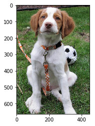

```python
predict_breed('images/Brittany_02625.jpg')
```

```
Detected a human face
If this person were a dog, the breed would be a Norwegian_lundehund
```

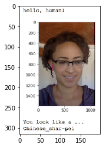

```python
predict_breed('images/sample_human_output.png')
```

```
Detected a dog
The breed of dog is a Labrador_retriever
```

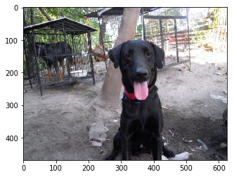

```python
predict_breed('images/Labrador_retriever_06449.jpg')
```

```
Detected a dog
The breed of dog is a Labrador_retriever
```

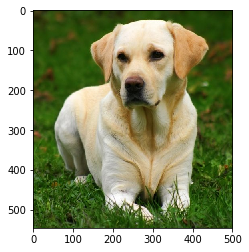

```python
predict_breed('images/Labrador_retriever_06457.jpg')
```

```
Detected a human face
If this person were a dog, the breed would be a Pointer
```

[figure not shown]

```python
predict_breed('images/1.jpeg')
```

```
Detected a human face
If this person were a dog, the breed would be a Yorkshire_terrier
```

[figure not shown]

```python
predict_breed('images/2.jpeg')
```

```
Detected a dog
The breed of dog is a Pointer
```

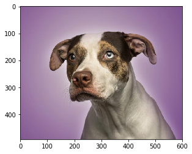

```python
predict_breed('images/6.jpg')
```

```
No human face or dog detected
```

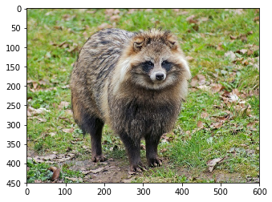

```python
predict_breed('images/8.jpeg')
```